# dung_beetle_rarefaction

Chloe Cho

2023-12-20

# Read and Clean Data

```r
beetle_counts <- read.delim("../Data/Dung_Beetle_Data.csv", sep = ",")
beetle_counts <- clean_names(beetle_counts)
head(beetle_counts)
```

```
##      date       farm  region temp  weather non_or_insecticide
## 1 5/18/22 Boone Farm Capital   60 Sunshine        Insecticide
## 2 5/25/22 Boone Farm Capital   66 Sunshine        Insecticide
## 3  6/1/22 Boone Farm Capital   68     Rain        Insecticide
## 4  6/7/22 Boone Farm Capital   71   Cloudy        Insecticide
## 5 6/14/22 Boone Farm Capital   68     Rain        Insecticide
## 6 6/22/22 Boone Farm Capital   56     Rain        Insecticide
##   active_ingredients calamosternus_granarius colobopterus_erraticus
## 1      Diflubenzuron                      NA                     20
## 2      Diflubenzuron                      NA                     NA
## 3      Diflubenzuron                       1                     32
## 4      Diflubenzuron                       1                      1
## 5      Diflubenzuron                       1                      2
## 6      Diflubenzuron                      NA                     NA
##   aphodius_fimetarius_pedellus otophorus_haemorrhoidalis oscarinus_rusicola
```

[output cut: 41 more lines]

```r
beetle_counts <- beetle_counts %>%
  mutate(non_or_insecticide = tolower(non_or_insecticide)) %>%
  mutate(weather = tolower(weather)) %>%
  mutate(farm = tolower(farm)) %>%
  mutate(active_ingredients = tolower(active_ingredients)) %>%
  mutate(region = tolower(region))

head(beetle_counts)
```

```
##      date       farm  region temp  weather non_or_insecticide
## 1 5/18/22 boone farm capital   60 sunshine        insecticide
## 2 5/25/22 boone farm capital   66 sunshine        insecticide
## 3  6/1/22 boone farm capital   68     rain        insecticide
## 4  6/7/22 boone farm capital   71   cloudy        insecticide
## 5 6/14/22 boone farm capital   68     rain        insecticide
## 6 6/22/22 boone farm capital   56     rain        insecticide
##   active_ingredients calamosternus_granarius colobopterus_erraticus
## 1      diflubenzuron                      NA                     20
## 2      diflubenzuron                      NA                     NA
## 3      diflubenzuron                       1                     32
## 4      diflubenzuron                       1                      1
## 5      diflubenzuron                       1                      2
## 6      diflubenzuron                      NA                     NA
##   aphodius_fimetarius_pedellus otophorus_haemorrhoidalis oscarinus_rusicola
```

[output cut: 41 more lines]

```r
beetle_counts <- beetle_counts %>%
  mutate(farm = as.factor(farm)) %>%
  mutate(region = as.factor(region)) %>%
  mutate(weather = as.factor(weather)) %>%
  mutate(non_or_insecticide = as.factor(non_or_insecticide)) %>%
  mutate(active_ingredients = as.factor(active_ingredients)) %>%
  mutate(date = as.factor(date)) %>%
  mutate(date = as.Date(date, format="%m/%d/%y"))
```

```r
beetle_counts <- beetle_counts %>%
  mutate(non_or_insecticide = case_when(non_or_insecticide == 'non   ' ~ 'non',
                                        non_or_insecticide == 'insecticide' ~ 'insecticide',
                                        non_or_insecticide == 'non' ~ 'non'))

beetle_counts <- beetle_counts %>%
  select(-c(date, region, temp, weather, non_or_insecticide, active_ingredients, gps, histeridae, hydrophilidae, staphylinidae, scarabaeidae, horn_flies, face_flies)) %>%
  rename(site = farm) %>%
  replace(is.na(.), 0)

beetle_counts <- beetle_counts %>%
  group_by(site) %>%
  summarise(across(everything(), sum))

farms <- c('chaseholm', 'eisele farm', 'honeyhill', 'johnk farm', 'turner', 'kuipers', 'rugenstein family farm', 'shephard farm', 'wallbridge', 'boone farm')
beetle_counts <- as.data.frame(t(beetle_counts[,-1]))
colnames(beetle_counts) <- farms

beetle_counts <- beetle_counts %>%
  rename(C_N = chaseholm)%>%
  rename(EF_N = `eisele farm`)%>%
  rename(H_N = honeyhill)%>%
  rename(JF_N = `johnk farm`)%>%
  rename(T_N = turner)%>%
  rename(K_I = kuipers)%>%
  rename(RF_I = `rugenstein family farm`)%>%
  rename(SF_I = `shephard farm`)%>%
  rename(W_I = wallbridge) %>%
  rename(BF_I = `boone farm`)

head(beetle_counts)
```

```
##                              C_N EF_N H_N JF_N T_N K_I RF_I SF_I W_I BF_I
## calamosternus_granarius        9   21  90   39  81 112  409    4   1    3
## colobopterus_erraticus       117  260  86  300 485 157   73  100  86  158
## aphodius_fimetarius_pedellus   6   23  21    4  15  37   34   18   8    1
## otophorus_haemorrhoidalis     85   66  26   22 122  13    9   23   5   73
## oscarinus_rusicola            10    0   0    0   4   1    0    2   0    0
## alloblackburneus_rubeolus      1    0   0    1  17   0    0    1   1    0
```

# Rarefaction Analysis for Abundance-Based Data

Abundance data - summed across the subplots within the locality.

- n = number of individuals
- S. obs = observed number of species in the locality.
- SC = sample coverage (estimated values of sampling completeness for each locality, between 0 and 1)

```r
DataInfo(beetle_counts, datatype = 'abundance')
```

```
##    Assemblage   n S.obs     SC f1 f2 f3 f4 f5 f6 f7 f8 f9 f10
## 1         C_N 273    12 0.9964  1  1  2  0  0  1  1  0  1   1
## 2        EF_N 406     9 0.9951  2  0  0  1  0  0  0  1  0   0
## 3         H_N 235     6 1.0000  0  1  0  0  0  0  0  0  0   1
## 4        JF_N 400     8 0.9950  2  0  0  1  0  0  0  0  0   1
## 5         T_N 842    13 1.0000  0  1  1  1  1  0  1  0  0   0
## 6         K_I 333     8 0.9910  3  0  0  0  0  0  0  0  0   0
## 7        RF_I 533     6 1.0000  1  0  0  0  0  0  1  0  1   0
## 8        SF_I 154    10 0.9808  3  3  0  1  0  0  0  0  0   0
## 9         W_I 133    10 0.9701  4  0  1  0  1  0  0  1  0   0
## 10       BF_I 257     8 0.9922  2  1  1  1  0  0  0  0  0   0
```

Draw rarefaction curves to see differences between localities. Dotted lines are extrapolated. We can see that the total number of individuals varies greatly between sites.

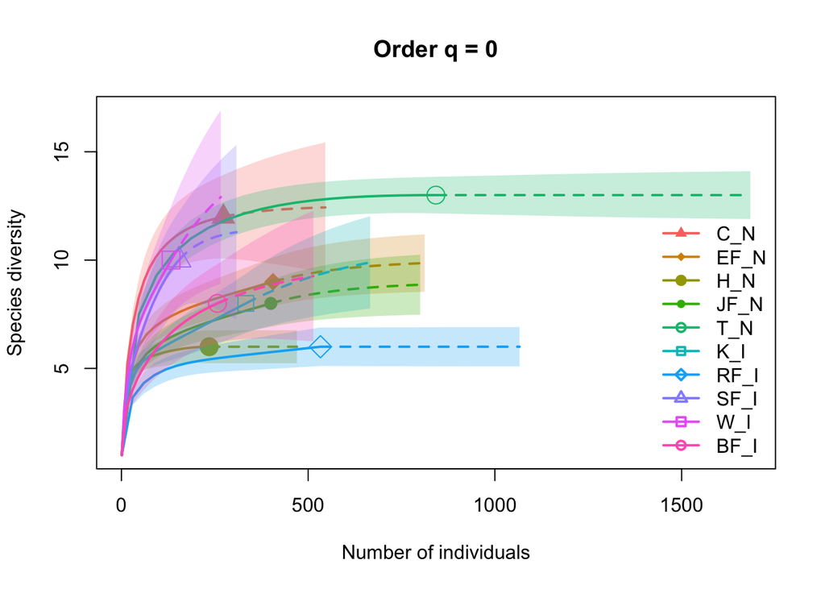

```r
D_abund <- iNEXT(beetle_counts, datatype = 'abundance')
plot(D_abund)
```

## Standarize to Number of Individuals

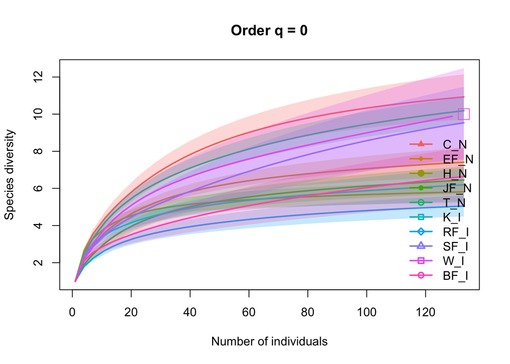

```r
D_abund_133 <- iNEXT(beetle_counts, datatype = 'abundance', endpoint = 133)
plot (D_abund_133)
```

Calculate estimated numbers. Column qD contains the estimated diversity for individual localities.

Orders:

- q = 0 for species richness
- q = 1 for Shannon diversity
- q = 2 for Simpson diversity

```r
est_D_abund <- estimateD (beetle_counts, datatype = 'abundance')
head(est_D_abund)
```

```
##   Assemblage   m      Method Order.q        SC        qD    qD.LCL    qD.UCL
## 1        C_N 266 Rarefaction       0 0.9961664 11.973772 10.363972 13.583573
## 2        C_N 266 Rarefaction       1 0.9961664  4.992129  4.337959  5.646299
## 3        C_N 266 Rarefaction       2 0.9961664  3.436082  2.980514  3.891650
## 4       EF_N 266 Rarefaction       0 0.9946713  8.296427  7.315196  9.277658
## 5       EF_N 266 Rarefaction       1 0.9946713  3.322969  2.922325  3.723613
## 6       EF_N 266 Rarefaction       2 0.9946713  2.239294  1.956966  2.521622
```

Filter out species richness.

```r
D_individuals <- D_individuals <- est_D_abund$qD[est_D_abund$Order.q == 0]

# filter(est_D_abund, Order.q == 0)

#D_individuals %>%
#  select(c(Assemblage, qD))
```

## Standardize to Sample Coverage

Plot the coverage rarefaction curve for each locality. Then plot the high end of the sample coverages.

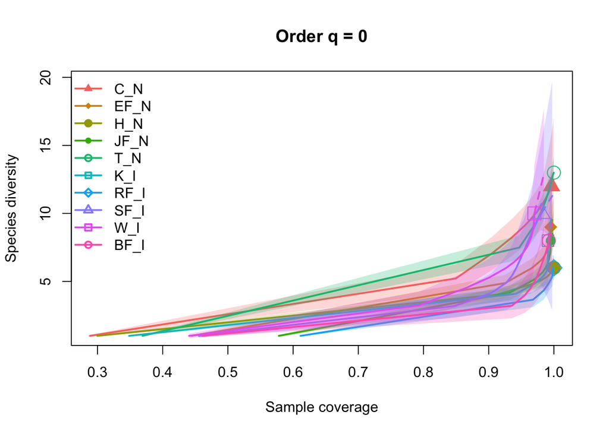

```r
plot(D_abund, type = 3)
```

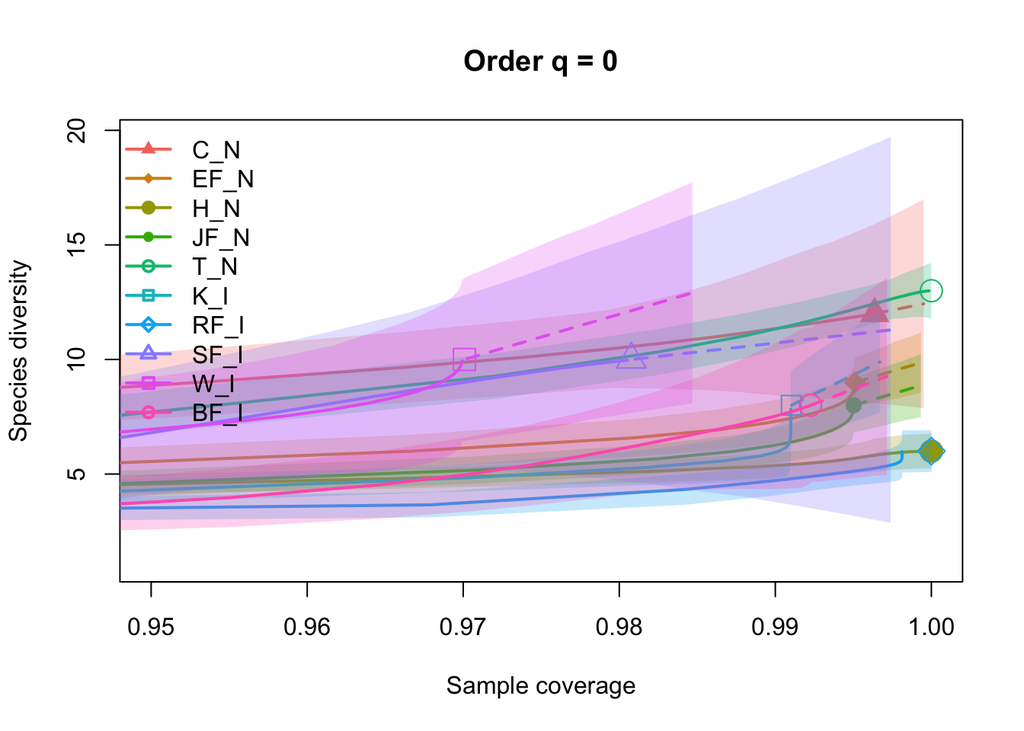

```r
plot (D_abund, type = 3, xlim = c(.95, 1))
```

Standardize the diversities to the lowest coverage, 0.984688. Filter again by species richness.

```r
est_D_abund_coverage <- estimateD(beetle_counts, datatype = 'abundance', base = 'coverage')
est_D_abund_coverage
```

```
##    Assemblage         m        Method Order.q       SC        qD   qD.LCL
## 1         C_N 128.75935   Rarefaction       0 0.984688 10.864853 9.161770
## 2         C_N 128.75935   Rarefaction       1 0.984688  4.865750 4.250712
## 3         C_N 128.75935   Rarefaction       2 0.984688  3.402740 2.970379
## 4        EF_N  81.23609   Rarefaction       0 0.984688  6.808149 6.109452
## 5        EF_N  81.23609   Rarefaction       1 0.984688  3.210651 2.923798
## 6        EF_N  81.23609   Rarefaction       2 0.984688  2.215725 2.008348
## 7         H_N  43.01997   Rarefaction       0 0.984688  5.191303 4.698452
## 8         H_N  43.01997   Rarefaction       1 0.984688  3.739483 3.397677
## 9         H_N  43.01997   Rarefaction       2 0.984688  3.164505 2.859222
## 10       JF_N  74.73433   Rarefaction       0 0.984688  5.798019 5.009331
## 11       JF_N  74.73433   Rarefaction       1 0.984688  2.450134 2.138819
## 12       JF_N  74.73433   Rarefaction       2 0.984688  1.713307 1.527935
## 13        T_N 156.75087   Rarefaction       0 0.984688 10.591252 9.580503
## 14        T_N 156.75087   Rarefaction       1 0.984688  4.178890 3.841279
```

[output cut: 47 more lines]

```r
D_coverage <- est_D_abund_coverage$qD[est_D_abund_coverage$Order.q == 0]

#filter(est_D_abund_coverage, Order.q == 0)

#D_coverage %>%
#  select(c(Assemblage, qD))
```

```r
# number of observed species at each locality
D_area <- DataInfo (beetle_counts, datatype = 'abundance')$S.obs

# add in the estimated species richness under standardization by individuals and sample coverage
D_est <- cbind (D_area, D_individuals, D_coverage)
rownames (D_est) <- DataInfo (beetle_counts, datatype = 'abundance')$Assemblage
```

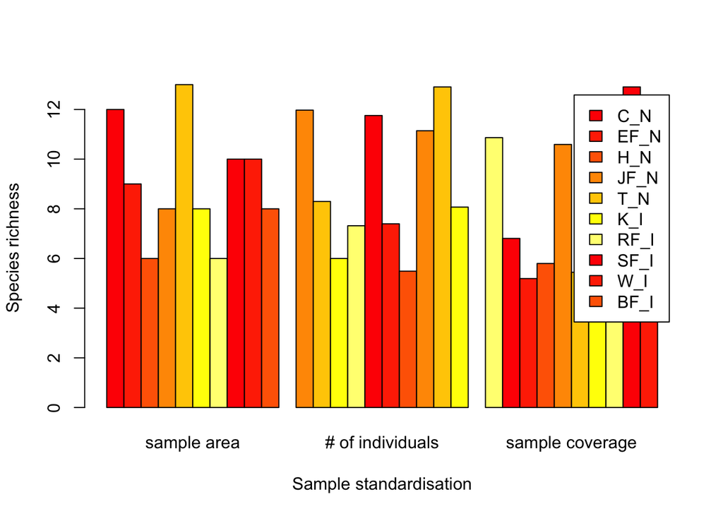

```r
barplot(D_est, beside = T, legend.text = T, col = heat.colors (7), xlab = 'Sample standardisation',
         ylab = 'Species richness', names.arg = c('sample area', '# of individuals', 'sample coverage'))
```

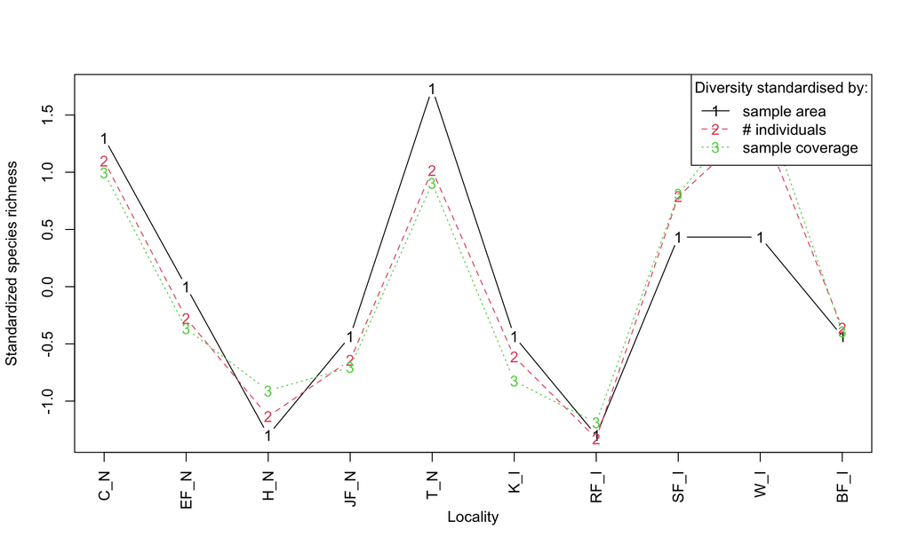

```r
matplot(scale (D_est), type = 'b', axes = F, xlab = 'Locality', ylab = 'Standardized species richness')
axis(1, at = 1:10, labels = rownames(D_est), las=2)
axis(2)
box()
legend('topright', title = 'Diversity standardised by:', legend = c('sample area', '# individuals', 'sample coverage'), pch = as.character(1:3), col = 1:3, lty = 1:3)
```

```r
D_est
```

```
##      D_area D_individuals D_coverage
## C_N      12     11.973772  10.864853
## EF_N      9      8.296427   6.808149
## H_N       6      6.000000   5.191303
## JF_N      8      7.317765   5.798019
## T_N      13     11.756557  10.591252
## K_I       8      7.396396   5.444569
## RF_I      6      5.489600   4.356026
## SF_I     10     11.142282  10.303581
## W_I      10     12.907801  12.907801
## BF_I      8      8.068690   6.721984
```

```r
treatments <- c('N', 'N', 'N', 'N', 'N', 'I', 'I', 'I', 'I', 'I')
treatments
```

```
##  [1] "N" "N" "N" "N" "N" "I" "I" "I" "I" "I"
```

```r
D_est <- cbind(D_est, treatments)
D_est <- as.data.frame(D_est)
D_est <- D_est %>%
  mutate(D_area = as.numeric(D_area)) %>%
  mutate(D_individuals = as.numeric(D_individuals)) %>%
  mutate(D_coverage = as.numeric(D_coverage)) %>%
  mutate(treatments = as.factor(treatments))
D_est
```

```
##      D_area D_individuals D_coverage treatments
## C_N      12     11.973772  10.864853          N
## EF_N      9      8.296427   6.808149          N
## H_N       6      6.000000   5.191303          N
## JF_N      8      7.317765   5.798019          N
## T_N      13     11.756557  10.591252          N
## K_I       8      7.396396   5.444569          I
## RF_I      6      5.489600   4.356026          I
## SF_I     10     11.142282  10.303581          I
## W_I      10     12.907801  12.907801          I
## BF_I      8      8.068690   6.721984          I
```

Plot observed number of species in insecticide vs. non-insecticide plots.

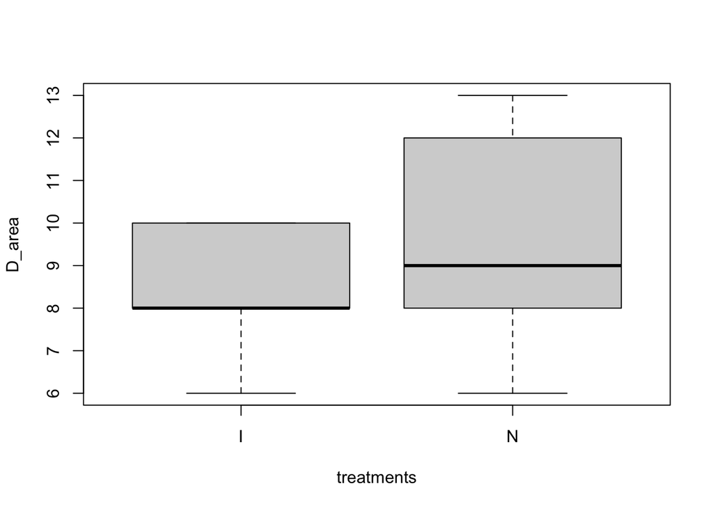

```r
plot(D_area ~ treatments, data=D_est)
```

```r
t.test(D_area ~ treatments, data=D_est)
```

```
##
##  Welch Two Sample t-test
##
## data:  D_area by treatments
## t = -0.80539, df = 6.423, p-value = 0.4494
## alternative hypothesis: true difference in means between group I and group N is not equal to 0
## 95 percent confidence interval:
##  -4.788393  2.388393
## sample estimates:
## mean in group I mean in group N
##             8.4             9.6
```

Plot number of species standardized by number of individuals in insecticide vs. non-insecticide plots.

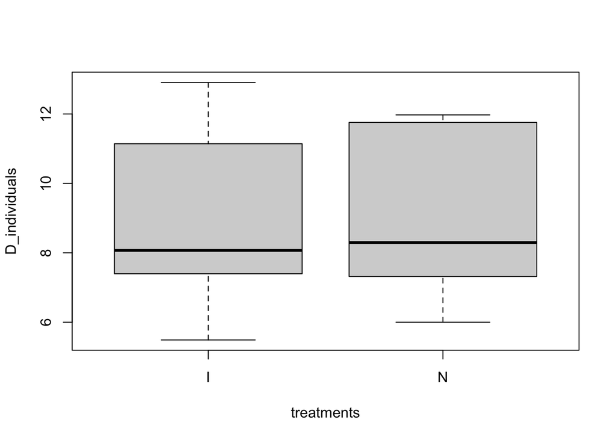

```r
plot(D_individuals ~ treatments, data=D_est)
```

```r
t.test(D_individuals ~ treatments, data=D_est)
```

```
##
##  Welch Two Sample t-test
##
## data:  D_individuals by treatments
## t = -0.037878, df = 7.9097, p-value = 0.9707
## alternative hypothesis: true difference in means between group I and group N is not equal to 0
## 95 percent confidence interval:
##  -4.213048  4.077147
## sample estimates:
## mean in group I mean in group N
##        9.000954        9.068904
```

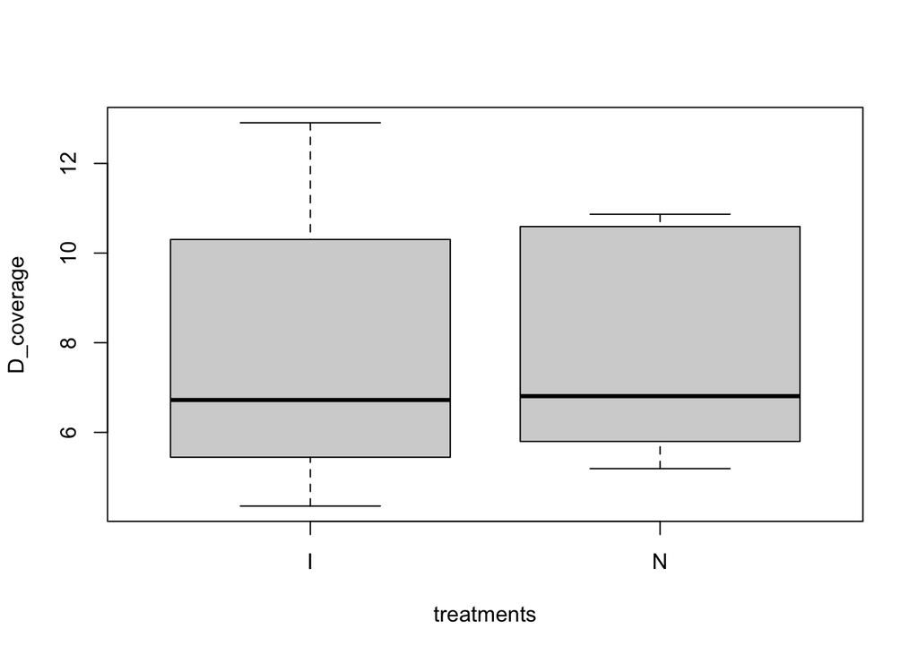

```r
plot(D_coverage ~ treatments, data=D_est)
```

```r
t.test(D_coverage ~ treatments, data=D_est)
```

```
##
##  Welch Two Sample t-test
##
## data:  D_coverage by treatments
## t = 0.048102, df = 7.4418, p-value = 0.9629
## alternative hypothesis: true difference in means between group I and group N is not equal to 0
## 95 percent confidence interval:
##  -4.570693  4.762848
## sample estimates:
## mean in group I mean in group N
##        7.946792        7.850715
```